# Trinity University Football

## Offensive EPA Analysis Report

## Executive Summary

### What We Set Out to Do

This project brings an advanced analytical framework to Trinity University Football. The goal is straightforward: **move beyond box score statistics and understand the true value of every offensive play we run.**

Traditional metrics — total yards, yards per carry, completion percentage — tell us *what happened*, but strip away the context that determines whether a play was actually *good*. A 4-yard gain on 3rd-and-3 is a success. A 4-yard gain on 3rd-and-10 is a failure. Averages cannot tell the difference. EPA can.

### Why Expected Points Added (EPA)?

**Expected Points (EP)** is the foundation of this model. At any point in a game, given the down, distance, and field position, we can estimate how many points a team is *expected* to score on the current drive. EPA measures how much a single play moves that expectation — up or down.

> A play with **EPA > 0** helped us. It moved the chains, created a favorable down-and-distance, or threatened scoring. A play with **EPA < 0** hurt us — it put us behind schedule, forced a tough 3rd down, or stalled a drive.

This framework lets us:

- **Compare plays across all situations** on a level playing field
- **Identify schematic strengths and weaknesses** that yardage totals obscure
- **Quantify the cost of bad plays**, not just celebrate the good ones
- **Understand situational efficiency** — 3rd down, red zone, two-minute drill — with precision

**Model baseline: +0.028 EPA per play.** Beating this consistently is what separates productive offensive series from stalled drives.

### Questions This Report Answers

1. Are we generating positive value play-to-play?
2. Where situationally do we succeed — and where do we fail?
3. Are we running the right plays in the right situations?
4. Does our scheme (personnel, formation) produce value?
5. Are we generating explosive plays, and from where?
6. How do our drives actually unfold?
7. What separates our wins from our losses?

## Setup — Libraries & Data Load

## Data Reshaping

Normalize team and opponent naming so every row in the dataset carries a consistent `team_name` and `opp_name`, derived from offensive play rows where `odk == 'o'`.

## 1 · Is Our Offense Generating Positive Value?

### EPA by Down

**What it shows:** Average EPA per play on 1st through 4th down compared to the model baseline (+0.028). This is the entry-level question — are we playing *ahead of schedule* or constantly putting ourselves in difficult situations?

- **1st down** → are we winning the line of scrimmage early?
- **2nd down** → are we setting up manageable 3rd downs?
- **3rd down** → are drives extending or dying?

> **So what?** If 1st down EPA is below baseline, our opening play design needs attention — play-action, RPO, and early motion can prevent 2nd-and-long from becoming the default. Negative 3rd down EPA feeds directly into the next section.

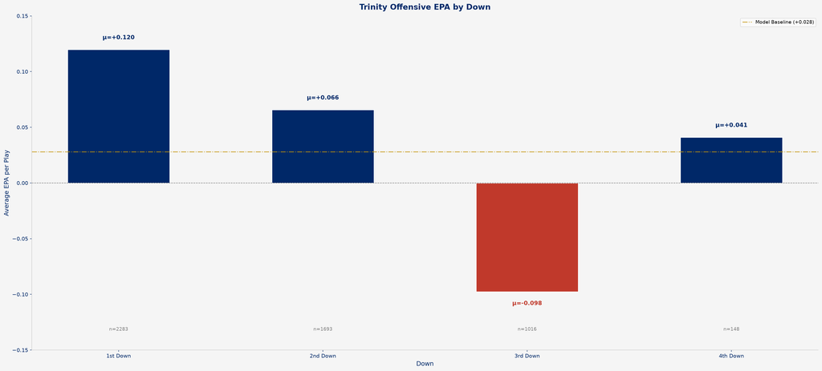

## 2 · EPA vs. Our Opponents

**What it shows:** Average offensive EPA per play for every game, filterable by season and by individual opponent. Color encodes win (green) vs. loss (red).

> **So what?** Identify opponents against whom we consistently struggle — their scheme warrants targeted pre-game adjustments. Year-over-year clustering of negative-EPA games signals a systemic issue, not just a bad week.

[interactive chart not shown]

## 3 · The 3rd Down Problem

**What it shows:** 3rd down EPA and conversion rate sliced by distance-to-go bucket. Left panel: EPA distribution (box plot). Right panel: conversion rate vs. average EPA.

| Bucket | Distance | Interpretation |
| --- | --- | --- |
| Short | ≤3 yards | Must-convert — we should win these |
| Medium | 4–7 yards | Execution dependent |
| Standard | 8–10 yards | Difficult — requires a chunk gain |
| Long | 11+ yards | Damage control |

> **So what?** Short 3rd downs should convert at 60–70%+. If they don't, short-yardage personnel and play design need dedicated practice time. Standard and Long 3rd downs are drive-killers — minimizing their *frequency* (through better 1st/2nd down execution) is often more valuable than the play call once you're in them.

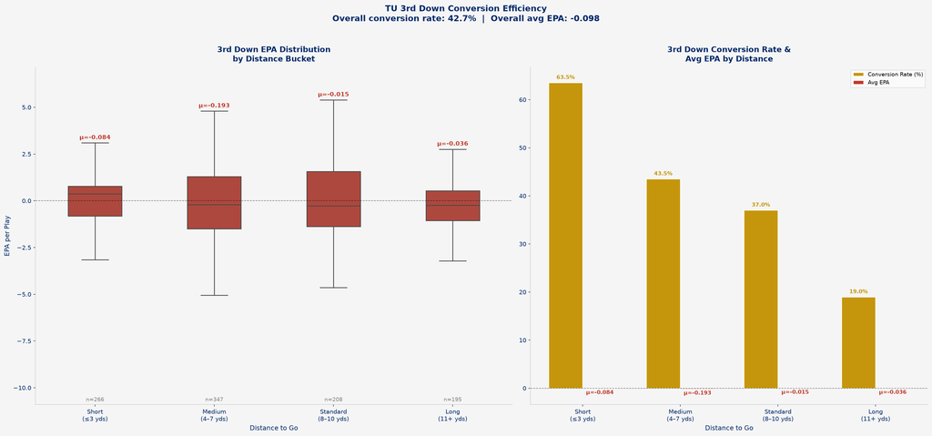

## 4 · 3rd Down: Run vs. Pass by Distance

**What it shows:** Mean EPA and play volume for runs vs. passes on 3rd down, broken out by distance bucket.

> **So what?** If pass EPA is significantly higher than run EPA across all distances, 3rd-down run calls are not converting and should be limited to short-yardage only. Watch the volume panel for predictability — if we pass 90%+ on 3rd-and-long, defenses already know what's coming.

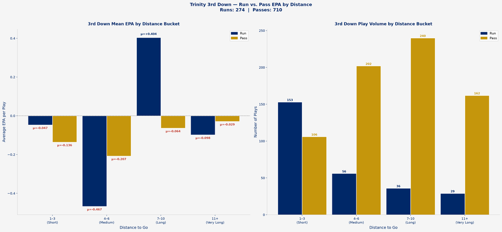

## 5 · Run vs. Pass EPA by Down

**What it shows:** Mean EPA and play volume for runs vs. passes on 1st, 2nd, and 3rd down across the full dataset.

> **So what?** 1st down run EPA is the single best indicator of our offensive foundation. If we cannot generate positive EPA running on 1st down, we play from behind all game. The volume panel reveals whether our play-calling philosophy matches what the EPA data supports.

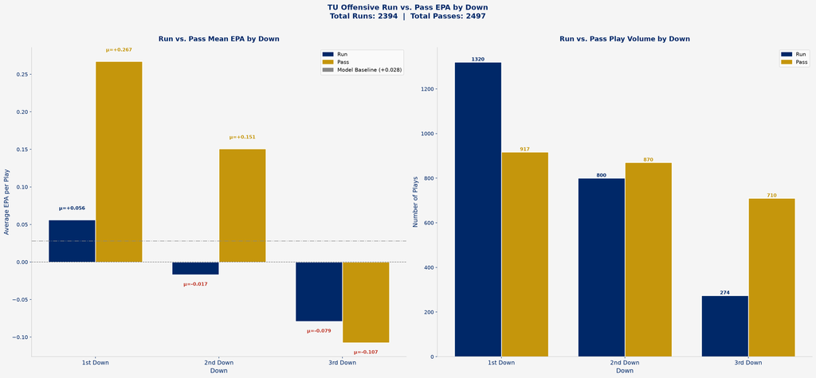

## 6 · Where on the Field Do We Succeed?

**What it shows:** Average EPA by field zone, from deep in our own territory (76–99 yards to go) through the red zone (1–20 yards to go).

> **So what?** Midfield (41–60 yards) is where drives are built or broken. Red zone EPA is the most consequential single number — if it's below the baseline, we are leaving points on the field every week.

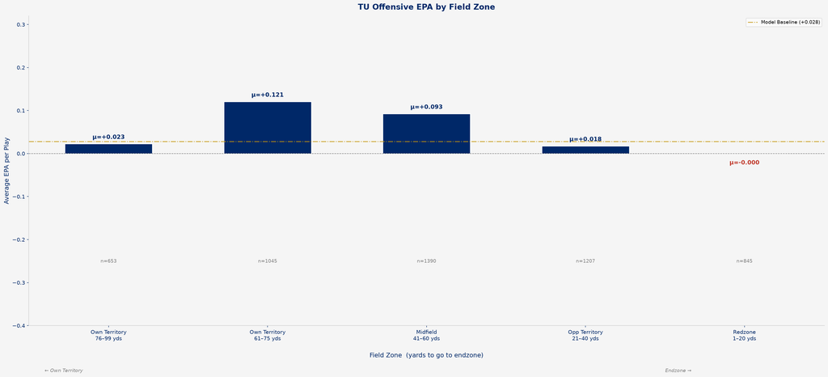

## 7 · Red Zone Efficiency by Down

**What it shows:** Average EPA per play in the red zone (yards to go ≤ 20), broken out by down. The compressed field gives defenses a structural advantage, so positive EPA here is genuinely difficult and highly valuable.

> **So what?** Negative 3rd down red zone EPA means we are leaving the red zone with field goals or punts far too often. Every point left on the field in the red zone is a direct loss of win probability.

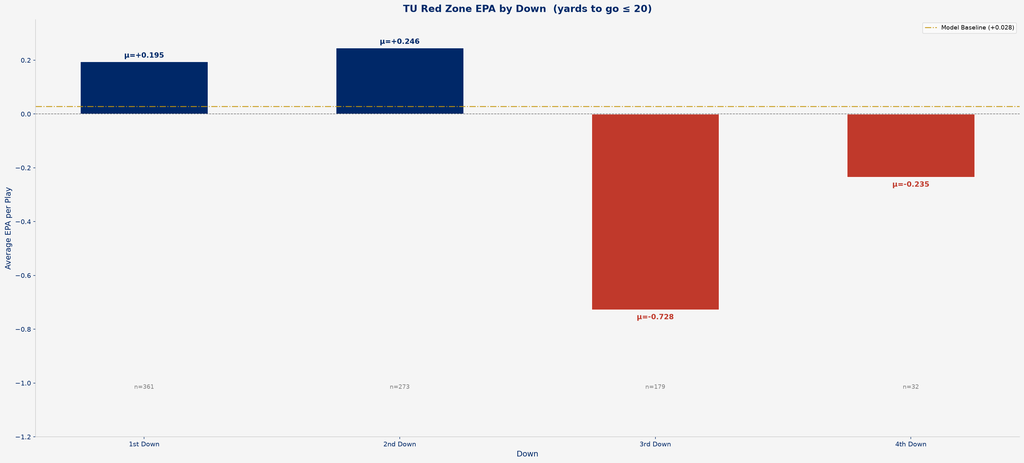

## 8 · Red Zone: Run vs. Pass

**What it shows:** Mean EPA and play volume for runs vs. passes by down inside the red zone (yards to go ≤ 20).

> **So what?** In the red zone, defenses sell out. Look at run/pass split percentage — if one type makes up 70%+ of our snaps, defenses will adjust. Maintaining balance, even when one type has a slight EPA edge, keeps coordinators honest.

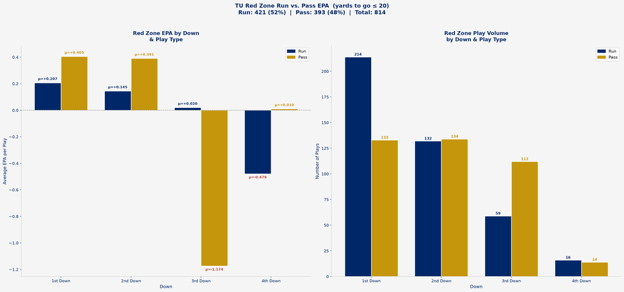

## 9 · How Plays Finished — EPA by Result Type

**What it shows:** Distribution of EPA for each play result type (Rush, Complete, Incomplete, Sack, Interception, etc.), ordered by median EPA. Box plots show the full distribution, not just the average.

> **So what?** Interceptions and sacks carry extreme negative EPA — eliminating one per game may be worth several explosive plays. If scramble EPA is positive, quarterback mobility is creating real value and should be schemed for, not just tolerated.

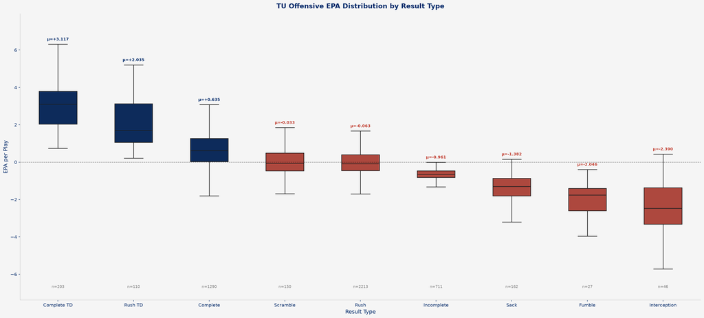

## 10 · Run vs. Pass EPA Distribution

**What it shows:** Full EPA distribution (box + strip plot) for all runs vs. all passes across the dataset. Mean markers show where each type sits on average.

> **So what?** The shape of the distribution matters as much as the mean. A wide distribution means high upside but also higher risk. If run EPA mean is below zero, our rushing attack is hurting us more than helping in aggregate — not a reason to stop running, but a signal to be more selective about when and how.

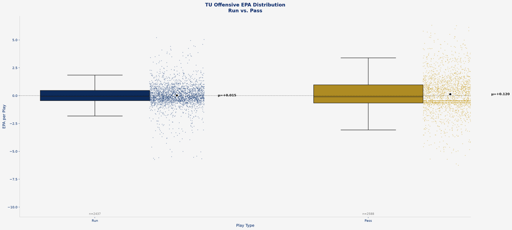

## 11 · EPA by Distance to Go

**What it shows:** Average EPA across all offensive plays grouped by distance-to-gain bucket. Covers all downs — not just 3rd.

> **So what?** Long-distance situations (11+ yards) are a red flag regardless of the play result. Getting into 2nd-and-12 or 3rd-and-14 frequently means 1st and 2nd down execution is breaking down upstream. Preventing long-distance is often more important than the play call once you're in it.

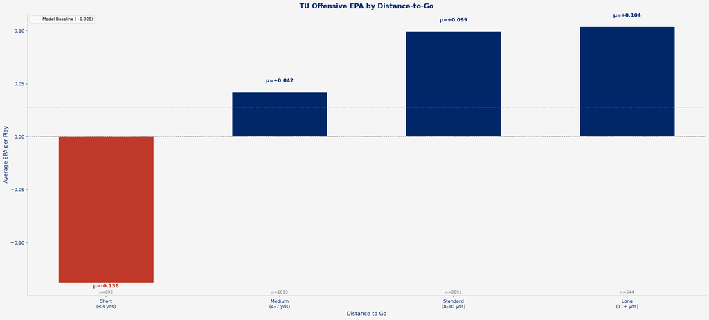

## 12 · Our Scheme — Personnel & Formation

### 12a · EPA by Personnel Grouping

**What it shows:** Average EPA for each personnel package (minimum 20 snaps), sorted highest to lowest.

> **So what?** Rank your personnel groupings by EPA and ask whether your usage matches that ranking. Your most productive package should be getting the most snaps — unless there is a specific situational reason otherwise.

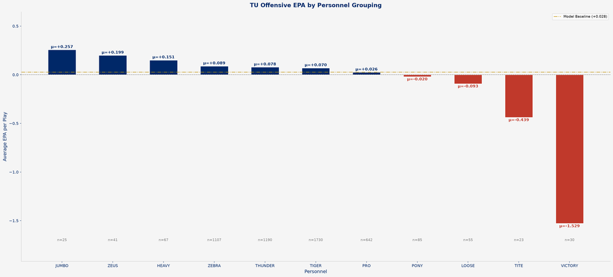

### 12b · EPA by Formation

**What it shows:** Average EPA by offensive formation (minimum 20 snaps), with RIGHT/LEFT directional variants collapsed into their base formation name.

> **So what?** If one formation dramatically outperforms others within the same personnel package, ask why — is it a blocking angle, a route concept, or a coverage exploit? Replicate what's working. Low-EPA formations with high usage are a scheme inefficiency you can correct immediately.

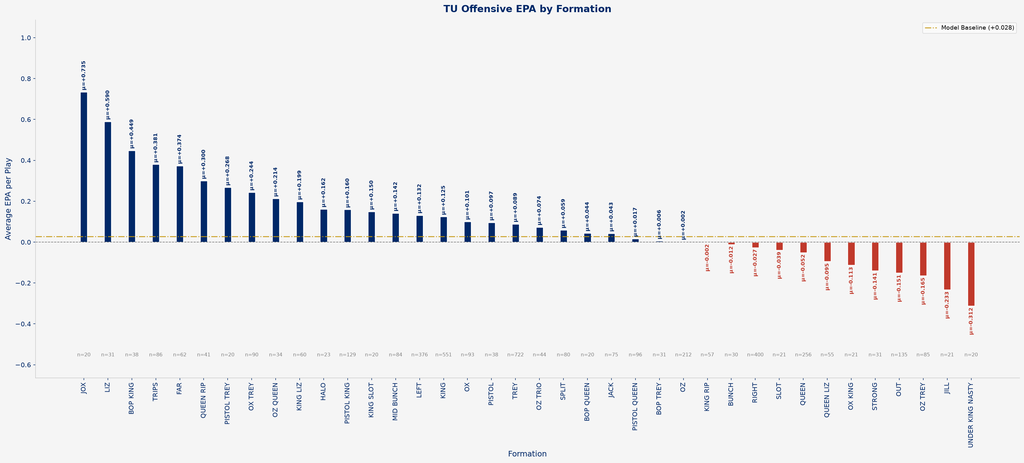

### 12c · EPA by Personnel & Formation Combination (Interactive)

**What it shows:** Interactive grouped bar chart — click a personnel group in the legend to display its formation-level EPA breakdown. Use Show All / Hide All to compare across groups.

> **So what?** This is the most actionable schematic chart in the report. Before each game, identify which personnel/formation combinations have the highest EPA and build your game plan around them — especially against opponents whose defensive tendencies suggest vulnerability to those looks.

[interactive chart not shown]

### 12d · Explosive Rate by Personnel

**What it shows:** Left panel — explosive play rate (%) per personnel group. Right panel — mean EPA per personnel group in the same sort order. A personnel package with both high explosive rate and high EPA is your best look.

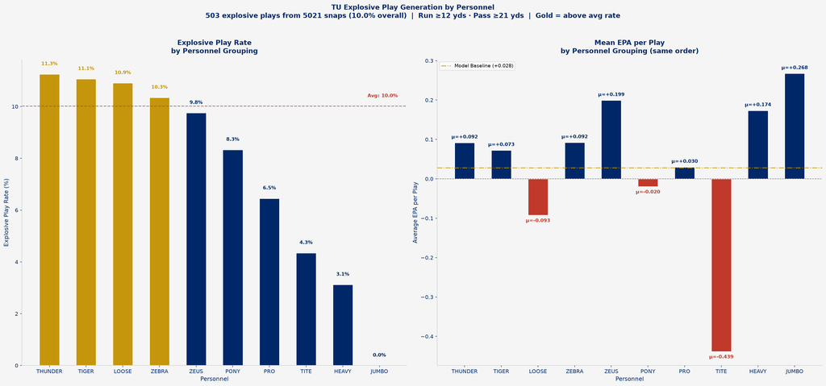

## 13 · Explosive Plays

### 13a · Explosive vs. Non-Explosive EPA

**What it shows:** Left — distribution comparison between explosive plays (run ≥12 yds, pass ≥21 yds) and non-explosive plays. Right — total EPA contribution split between the two categories.

> **So what?** If explosive plays account for the majority of our total EPA, our offense is variance-dependent. One or two explosives per game may be the difference between a 400-yard performance and a stalled drive night. We need to complement explosives with consistent drive-building efficiency.

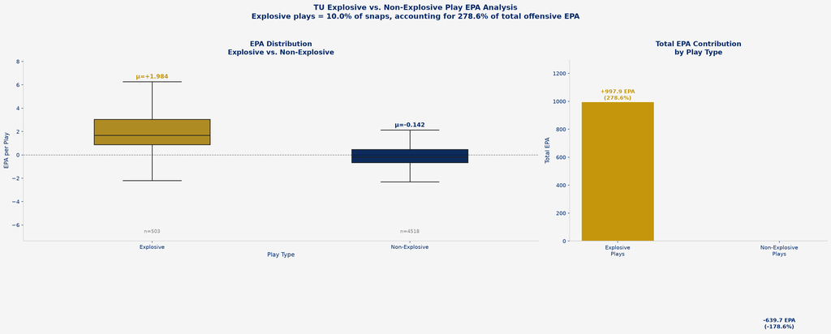

### 13b · Explosive Plays by Field Position

**What it shows:** Left — explosive play count and rate by field zone, with a rate line overlay. Right — mean EPA of explosive plays by zone.

> **So what?** Explosive play rate is a controllable schematic variable — it is not random. If our rate is highest at midfield but drops near zero in opponent territory, defenses are loading up once we cross the 40. Motions, shifts, and tempo changes can disrupt that loading tendency.

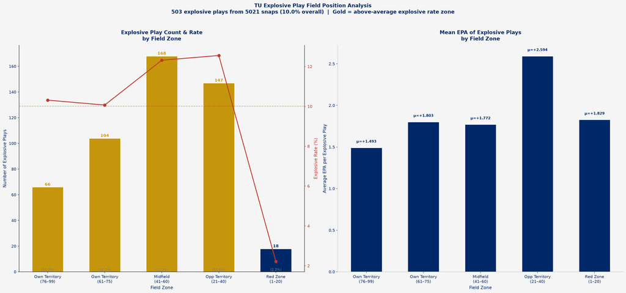

## 14 · Drive Narrative

### 14a · Cumulative Offensive EPA by Drive Series (Season Aggregate)

**What it shows:** Cumulative EPA accumulation across all offensive series in the dataset. A rising line means consistent value addition; a flat or declining line means drives are breaking even or costing us.

> **So what?** The shape of this curve is your season's offensive story in one line. Sharp upward turns mark run-game dominance or explosive play stretches. Flat sections reveal extended stretches of stalled drives.

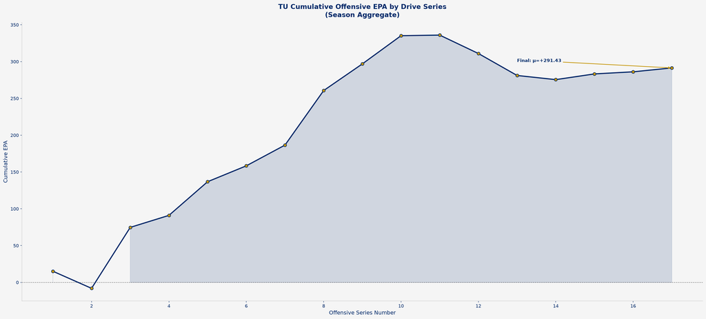

### 14b · Cumulative EPA Per Game — Interactive

**What it shows:** Drive-by-drive cumulative EPA for each individual game, togglable by season and color-coded by year or W/L result.

> **So what?** Compare drive trajectories across games to identify whether winning games follow a different pattern than losses. Games where EPA builds steadily indicate sustained efficiency; games with one sharp spike and then flat lines indicate explosion-dependent offense.

[interactive chart not shown]

### 14c · Drive Process — Outcomes & Trajectories (Interactive)

**What it shows:** Top panel — every drive plotted as net EPA vs. drive points, color-coded by outcome (Touchdown, Field Goal, Punt, Turnover, etc.). Bottom panel — normalized drive EPA trajectories (thin = individual drives, bold = outcome average), showing the *shape* of how drives unfold from first to last play.

> **So what?** Drives that end in turnovers often show a characteristic EPA decline before the play occurs. Touchdown drives typically build differently than punt drives. The drive process panel makes those patterns visible.

[interactive chart not shown]

## 15 · The Win/Loss Fingerprint

**What it shows:** Radar chart comparing eight offensive metrics between wins and losses. The larger the gap between the two polygons on any axis, the more predictive that metric is of game outcome. Filterable by season year.

| Metric | What It Measures |
| --- | --- |
| 1st Down EPA | Early down efficiency |
| 2nd Down EPA | Schedule maintenance |
| 3rd Down EPA | Conversion efficiency |
| Run EPA | Rushing effectiveness |
| Pass EPA | Passing effectiveness |
| Red Zone EPA | Scoring zone execution |
| Explosive EPA | Big play generation |
| 3rd Down Conv Rate | Sustained drive rate |

> **So what?** The metric with the largest gap between wins and losses is your program's pressure point. Use this chart year-over-year as a report card — if last year's gap in 3rd down EPA has closed, that is measurable program improvement.

[interactive chart not shown]

## Closing Note

This analysis represents the first full cycle of EPA-based performance evaluation for Trinity University Football. The goal was never to replace the coach's eye — it is to give it context. The numbers confirm what great coaches already feel, and they surface what is easy to miss in the flow of a season.

The next phase of this project will extend this framework to **defensive EPA analysis** and, ultimately, **individual player-level EPA attribution** — giving us the ability to evaluate not just *what* we are calling, but *who* is executing it and at what efficiency.

*Analysis conducted using a custom EPA model built on multi-season TUFB play-by-play data. Model baseline: +0.028 EPA/play. All visualizations generated in Python (matplotlib, seaborn, plotly).*